# Connecting points in Normal Probability Plot

We’re going to connect all the points in a normal probability plot with lines. There will actually be one normal probability plot for each level of a categorical variable. **The dataset used is the *nc* dataset from Duke’s Coursera’s statsr package**

## Load packages

```r
library(dplyr)
library(magrittr)
library(statsr)
```

## Load data

```r
data(nc)
```

Here’s a regular normal probability plot of the *weight* variable on nonmissing levels of the *habit* variable. By “regular” I mean that we’re not connecting the points with lines.

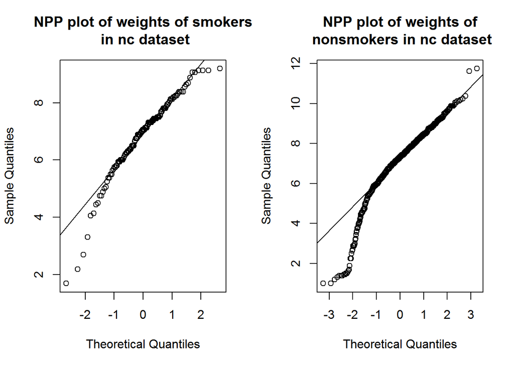

```r
ncSmokers<-nc%>%filter(habit=="smoker")
ncNonsmokers<-nc%>%filter(habit=="nonsmoker")

par(mfrow=c(1,2))

qqnorm(ncSmokers$weight,main="NPP plot of weights of smokers\n in nc dataset")
qqline(ncSmokers$weight)

qqnorm(ncNonsmokers$weight,main="NPP plot of weights of\n nonsmokers in nc dataset")
qqline(ncNonsmokers$weight)
```

Now here’s a normal probability plot of the *weight* variable on nonmissing levels of the habit variable wherein datapoints are connected by lines. What seems wrong with it?

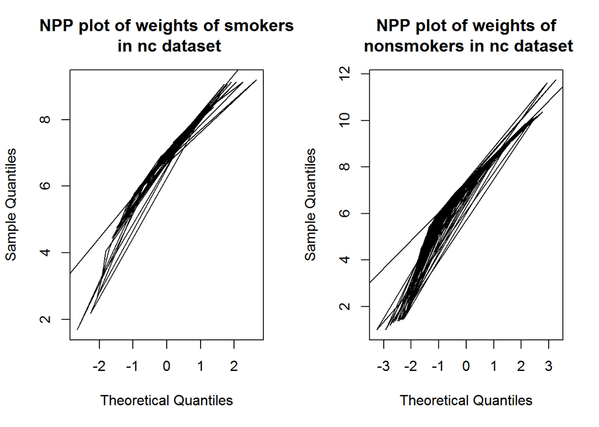

```r
par(mfrow=c(1,2))

qqnorm(ncSmokers$weight,main="NPP plot of weights of smokers\n in nc dataset",type="l")
qqline(ncSmokers$weight)

qqnorm(ncNonsmokers$weight,main="NPP plot of weights of\n nonsmokers in nc dataset",type="l")
qqline(ncNonsmokers$weight)
```

**The plot doesn’t *seem* to reflect the data. Here’s what’s going on. The lines connect points in the order that they appear in the dataset- i.e. the point is not necessarily going to be connected to its lexicographic successor- this is necessary for the plot to look as you want it. To make this so, we’ll sort each subsample by weight before plotting it.**

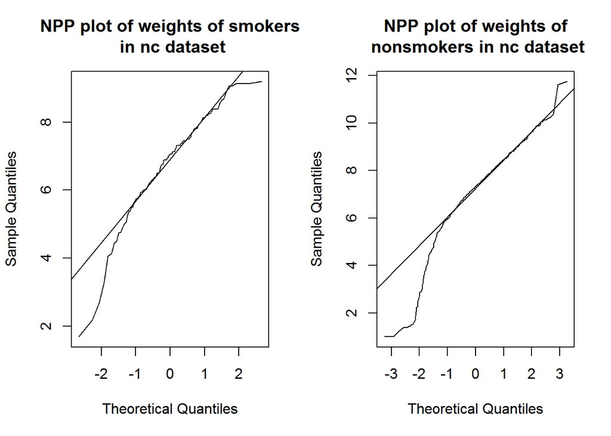

```r
par(mfrow=c(1,2))

ncSmokers<-arrange(ncSmokers,weight)
qqnorm(ncSmokers$weight,main="NPP plot of weights of smokers\n in nc dataset",type="l")
qqline(ncSmokers$weight)

ncNonsmokers<-arrange(ncNonsmokers,weight)
qqnorm(ncNonsmokers$weight,main="NPP plot of weights of\n nonsmokers in nc dataset",type="l")
qqline(ncNonsmokers$weight)
```

**Ah- much better!**